# Exploration of Physical Activity Data by Nivedita Bijlani

This report explores the physical activity data obtained from the National Health and Nutrition Examination Survey (NHANES) 2013. NHANES is a program of studies designed to assess the health and nutritional status of adults and children in the United States. This data set is included in the “aplore3” R package. The data dictionary is also included as a separate Word file for reference.

# Univariate Plots Section

The structure of the data set is described in the accompanying Word file. Let us begin by getting an intuition of our data set, exploring the structure and data summary for each variable.

```
## 'data.frame':    6482 obs. of  21 variables:
##  $ id       : int  1 2 3 4 5 6 7 8 9 10 ...
##  $ gender   : Factor w/ 2 levels "Male","Female": 1 1 2 1 2 1 1 1 2 1 ...
##  $ age      : int  34 16 60 26 49 80 80 17 42 66 ...
##  $ marstat  : Factor w/ 6 levels "Married","Widowed",..: 1 NA 2 1 6 1 2 NA 1 1 ...
##  $ samplewt : num  80101 13953 20090 22538 74212 ...
##  $ psu      : int  1 1 2 1 2 1 1 1 2 1 ...
##  $ strata   : int  9 10 1 14 11 3 5 7 1 1 ...
##  $ tchol    : int  135 192 202 160 259 182 148 178 170 217 ...
##  $ hdl      : int  50 60 45 45 45 75 49 66 35 40 ...
##  $ sysbp    : int  114 112 154 102 118 142 126 122 NA 146 ...
##  $ dbp      : int  88 62 70 50 82 62 62 76 NA 68 ...
##  $ wt       : num  87.4 72.3 116.8 97.6 86.7 ...
##  $ ht       : num  165 181 166 173 168 ...
##  $ bmi      : num  32.2 22 42.4 32.6 30.6 ...
##  $ vigwrk   : Factor w/ 2 levels "Yes","No": 2 2 2 2 2 2 2 2 2 2 ...
##  $ modwrk   : Factor w/ 2 levels "Yes","No": 2 2 2 2 2 1 1 1 2 2 ...
##  $ wlkbik   : Factor w/ 2 levels "Yes","No": 2 1 2 1 2 1 2 2 2 2 ...
##  $ vigrecexr: Factor w/ 2 levels "Yes","No": 2 2 2 1 2 2 2 1 2 2 ...
##  $ modrecexr: Factor w/ 2 levels "Yes","No": 2 1 2 2 2 1 2 1 2 2 ...
##  $ sedmin   : int  480 240 240 720 240 60 540 480 30 NA ...
##  $ obese    : Factor w/ 2 levels "No","Yes": 1 1 2 1 1 1 1 1 2 1 ...
```

```
##        id          gender          age                   marstat
##  Min.   :   1   Male  :3164   Min.   :16.00   Married        :3019
##  1st Qu.:1621   Female:3318   1st Qu.:30.00   Widowed        : 505
##  Median :3242                 Median :46.00   Divorced       : 643
##  Mean   :3242                 Mean   :46.34   Separated      : 195
##  3rd Qu.:4862                 3rd Qu.:62.00   Never Married  :1034
##  Max.   :6482                 Max.   :80.00   Living Together: 457
##                                               NA's           : 629
##     samplewt           psu           strata           tchol
##  Min.   :  4084   Min.   :1.00   Min.   : 1.000   Min.   : 90.0
##  1st Qu.: 16460   1st Qu.:1.00   1st Qu.: 4.000   1st Qu.:162.0
##  Median : 24217   Median :2.00   Median : 7.000   Median :188.0
##  Mean   : 34546   Mean   :1.51   Mean   : 7.225   Mean   :192.1
##  3rd Qu.: 50435   3rd Qu.:2.00   3rd Qu.:11.000   3rd Qu.:218.0
##  Max.   :153810   Max.   :2.00   Max.   :15.000   Max.   :383.0
##                                                   NA's   :395
##       hdl             sysbp          dbp               wt
##  Min.   : 11.00   Min.   : 90   Min.   : 40.00   Min.   : 33.20
##  1st Qu.: 41.00   1st Qu.:110   1st Qu.: 62.00   1st Qu.: 65.90
##  Median : 50.00   Median :120   Median : 70.00   Median : 77.60
##  Mean   : 52.41   Mean   :123   Mean   : 69.59   Mean   : 80.38
##  3rd Qu.: 61.00   3rd Qu.:132   3rd Qu.: 78.00   3rd Qu.: 91.80
##  Max.   :144.00   Max.   :220   Max.   :134.00   Max.   :159.10
##  NA's   :395      NA's   :553   NA's   :594      NA's   :37
##        ht             bmi         vigwrk      modwrk      wlkbik
##  Min.   :123.3   Min.   :13.18   Yes :1131   Yes :2190   Yes :1807
##  1st Qu.:160.0   1st Qu.:23.99   No  :5350   No  :4291   No  :4674
##  Median :166.9   Median :27.68   NA's:   1   NA's:   1   NA's:   1
##  Mean   :167.4   Mean   :28.62
##  3rd Qu.:175.0   3rd Qu.:32.15
##  Max.   :202.7   Max.   :65.19
##  NA's   :37      NA's   :37
##  vigrecexr   modrecexr       sedmin       obese
##  Yes :1402   Yes :2493   Min.   :  0.0   No  :5459
##  No  :5079   No  :3987   1st Qu.:180.0   Yes : 986
##  NA's:   1   NA's:   2   Median :300.0   NA's:  37
##                          Mean   :321.1
##                          3rd Qu.:480.0
##                          Max.   :840.0
##                          NA's   :79
```

We notice above that there is some missing data, most notably for Marital Status, Total Cholestrol, Systolic Blood Pressure and Diastolic Blood Pressure. To minimise speculation during analysis and to focus primarily on EDA rather than data pre-processing here, I will consider only complete records.

We will also ignore these these columns:

1. id - The person identifier in the survey
2. psu - The primary sampling unit
3. strata - Related to psu and provides geographical and population identification.
4. samplewt - According to NHANES survey design notes, the sample weight is the “number of people in the population represented by that sample person in NHANES, reflecting the unequal probability of selection, nonresponse adjustment, and adjustment to independent population controls”

Verify the trimmed-down data set has no missing data and review summary.

```
## 'data.frame':    4915 obs. of  17 variables:
##  $ gender   : Factor w/ 2 levels "Male","Female": 1 2 1 2 1 1 2 1 1 1 ...
##  $ age      : int  34 60 26 49 80 80 45 28 44 66 ...
##  $ marstat  : Factor w/ 6 levels "Married","Widowed",..: 1 2 1 6 1 2 1 5 3 1 ...
##  $ tchol    : int  135 202 160 259 182 148 225 299 197 193 ...
##  $ hdl      : int  50 45 45 45 75 49 82 51 37 26 ...
##  $ sysbp    : int  114 154 102 118 142 126 106 108 118 124 ...
##  $ dbp      : int  88 70 50 82 62 62 62 62 90 64 ...
##  $ wt       : num  87.4 116.8 97.6 86.7 79.1 ...
##  $ ht       : num  165 166 173 168 174 ...
##  $ bmi      : num  32.2 42.4 32.6 30.6 26 ...
##  $ vigwrk   : Factor w/ 2 levels "Yes","No": 2 2 2 2 2 2 2 2 2 2 ...
##  $ modwrk   : Factor w/ 2 levels "Yes","No": 2 2 2 2 1 1 1 2 2 1 ...
##  $ wlkbik   : Factor w/ 2 levels "Yes","No": 2 2 1 2 1 2 2 1 2 2 ...
##  $ vigrecexr: Factor w/ 2 levels "Yes","No": 2 2 1 2 2 2 1 1 2 2 ...
##  $ modrecexr: Factor w/ 2 levels "Yes","No": 2 2 2 2 1 2 1 1 2 1 ...
##  $ sedmin   : int  480 240 720 240 60 540 720 30 600 180 ...
##  $ obese    : Factor w/ 2 levels "No","Yes": 1 2 1 1 1 1 1 1 1 1 ...
```

```
##     gender          age                   marstat         tchol
##  Male  :2426   Min.   :20.00   Married        :2569   Min.   : 92.0
##  Female:2489   1st Qu.:34.00   Widowed        : 399   1st Qu.:166.0
##                Median :48.00   Divorced       : 537   Median :192.0
##                Mean   :49.27   Separated      : 160   Mean   :195.7
##                3rd Qu.:63.00   Never Married  : 841   3rd Qu.:221.0
##                Max.   :80.00   Living Together: 409   Max.   :383.0
##       hdl             sysbp          dbp               wt
##  Min.   : 15.00   Min.   : 90   Min.   : 40.00   Min.   : 33.20
##  1st Qu.: 41.00   1st Qu.:112   1st Qu.: 62.00   1st Qu.: 67.00
##  Median : 50.00   Median :122   Median : 70.00   Median : 78.50
##  Mean   : 52.75   Mean   :124   Mean   : 70.44   Mean   : 81.19
##  3rd Qu.: 62.00   3rd Qu.:134   3rd Qu.: 78.00   3rd Qu.: 92.60
##  Max.   :144.00   Max.   :220   Max.   :120.00   Max.   :159.10
##        ht             bmi        vigwrk     modwrk     wlkbik
##  Min.   :135.4   Min.   :13.18   Yes: 927   Yes:1763   Yes:1278
##  1st Qu.:160.1   1st Qu.:24.38   No :3988   No :3152   No :3637
##  Median :167.2   Median :28.04
##  Mean   :167.5   Mean   :28.88
##  3rd Qu.:175.0   3rd Qu.:32.34
##  Max.   :202.7   Max.   :64.97
##  vigrecexr  modrecexr      sedmin      obese
##  Yes: 925   Yes:1917   Min.   :  0.0   No :4147
##  No :3990   No :2998   1st Qu.:180.0   Yes: 768
##                        Median :300.0
##                        Mean   :311.3
##                        3rd Qu.:420.0
##                        Max.   :840.0
```

In order to remove redundancy, I’d like to analyse vigorous/moderate/no work activity as a single variable “workpattern” and similarly, vigorous/moderate/no recreational activity using a single variable “recrpattern”. Create these two new variables, and remove redundant variables. Then, revisit summary.

```
##     gender          age                   marstat         tchol
##  Male  :2426   Min.   :20.00   Married        :2569   Min.   : 92.0
##  Female:2489   1st Qu.:34.00   Widowed        : 399   1st Qu.:166.0
##                Median :48.00   Divorced       : 537   Median :192.0
##                Mean   :49.27   Separated      : 160   Mean   :195.7
##                3rd Qu.:63.00   Never Married  : 841   3rd Qu.:221.0
##                Max.   :80.00   Living Together: 409   Max.   :383.0
##       hdl             sysbp          dbp               wt
##  Min.   : 15.00   Min.   : 90   Min.   : 40.00   Min.   : 33.20
##  1st Qu.: 41.00   1st Qu.:112   1st Qu.: 62.00   1st Qu.: 67.00
##  Median : 50.00   Median :122   Median : 70.00   Median : 78.50
##  Mean   : 52.75   Mean   :124   Mean   : 70.44   Mean   : 81.19
##  3rd Qu.: 62.00   3rd Qu.:134   3rd Qu.: 78.00   3rd Qu.: 92.60
##  Max.   :144.00   Max.   :220   Max.   :120.00   Max.   :159.10
##        ht             bmi        wlkbik         sedmin      obese
##  Min.   :135.4   Min.   :13.18   Yes:1278   Min.   :  0.0   No :4147
##  1st Qu.:160.1   1st Qu.:24.38   No :3637   1st Qu.:180.0   Yes: 768
##  Median :167.2   Median :28.04              Median :300.0
##  Mean   :167.5   Mean   :28.88              Mean   :311.3
##  3rd Qu.:175.0   3rd Qu.:32.34              3rd Qu.:420.0
##  Max.   :202.7   Max.   :64.97              Max.   :840.0
##    workpattern     recrpattern
##  Moderate:1051   Moderate:1324
##  None    :2937   None    :2666
##  Vigorous: 927   Vigorous: 925
##
##
##
```

What is the age distribution of subjects?

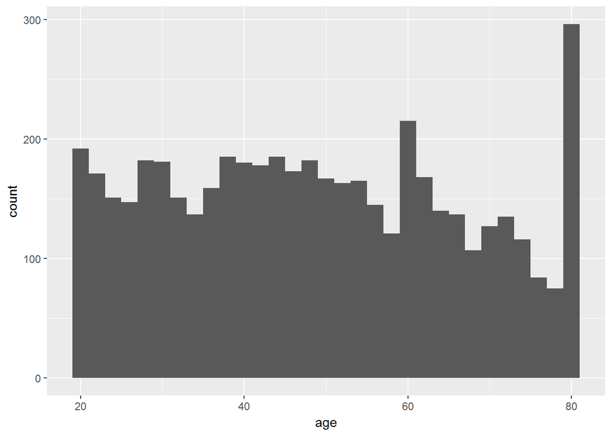

There seems to be an inordinately large number of subjects above 78 years of age. Maybe we will separate out this group for bivariate and multivariate analysis.

Now, let us look at the distribution of data by bmi. This is linked to obesity as subjects with bmi > 35 are classified in this data set as obese.

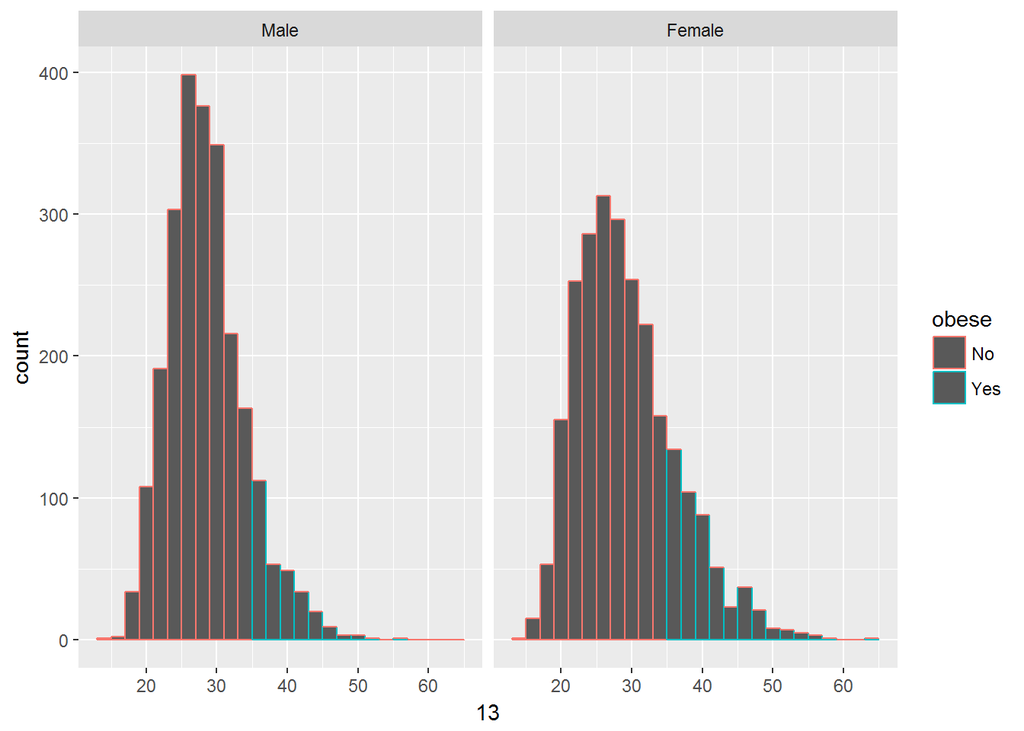

We see here the BMI for male subjects has a tighter distribution than for female subjects. There is a larger number of obese females.

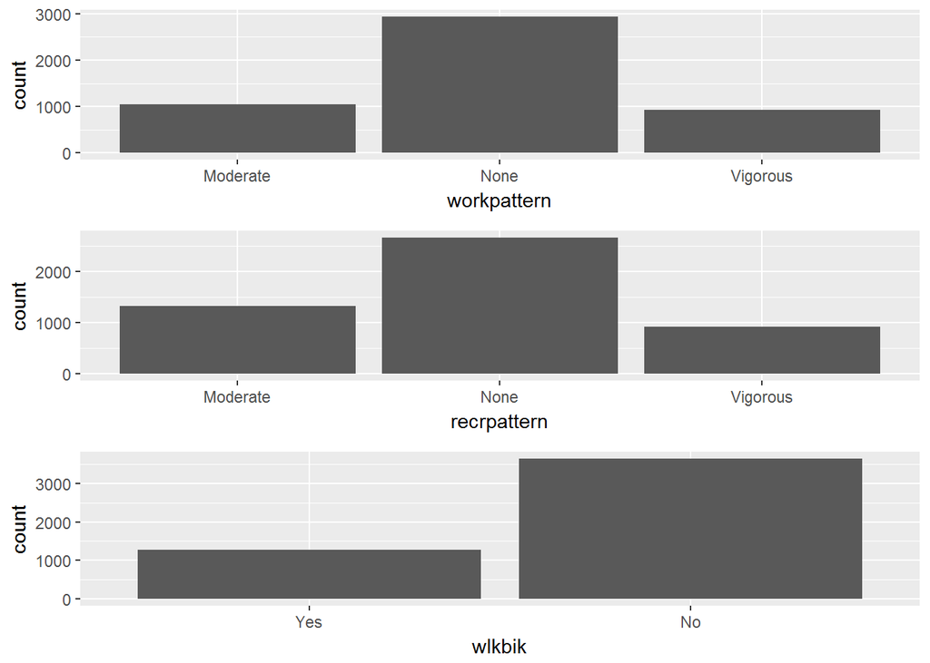

We see above that the vast majority of the subjects surveyed do not participate in moderate or vigorous work activity, recreational activity, walking or biking. A word of caution here, however! Let us not assume that most respondents are not active as these categories are not mutually exclusive! So, let us create a new variable called “active” that will label a subject as inactive if they do not engage in any of the above activities - work, recreational activity or walking/biking.

```
##     gender          age                   marstat         tchol
##  Male  :2426   Min.   :20.00   Married        :2569   Min.   : 92.0
##  Female:2489   1st Qu.:34.00   Widowed        : 399   1st Qu.:166.0
##                Median :48.00   Divorced       : 537   Median :192.0
##                Mean   :49.27   Separated      : 160   Mean   :195.7
##                3rd Qu.:63.00   Never Married  : 841   3rd Qu.:221.0
##                Max.   :80.00   Living Together: 409   Max.   :383.0
##       hdl             sysbp          dbp               wt
##  Min.   : 15.00   Min.   : 90   Min.   : 40.00   Min.   : 33.20
##  1st Qu.: 41.00   1st Qu.:112   1st Qu.: 62.00   1st Qu.: 67.00
##  Median : 50.00   Median :122   Median : 70.00   Median : 78.50
##  Mean   : 52.75   Mean   :124   Mean   : 70.44   Mean   : 81.19
##  3rd Qu.: 62.00   3rd Qu.:134   3rd Qu.: 78.00   3rd Qu.: 92.60
##  Max.   :144.00   Max.   :220   Max.   :120.00   Max.   :159.10
##        ht             bmi        wlkbik         sedmin      obese
##  Min.   :135.4   Min.   :13.18   Yes:1278   Min.   :  0.0   No :4147
##  1st Qu.:160.1   1st Qu.:24.38   No :3637   1st Qu.:180.0   Yes: 768
##  Median :167.2   Median :28.04              Median :300.0
##  Mean   :167.5   Mean   :28.88              Mean   :311.3
##  3rd Qu.:175.0   3rd Qu.:32.34              3rd Qu.:420.0
##  Max.   :202.7   Max.   :64.97              Max.   :840.0
##    workpattern     recrpattern   active
##  Moderate:1051   Moderate:1324   No :1328
##  None    :2937   None    :2666   Yes:3587
##  Vigorous: 927   Vigorous: 925
##
##
##
```

We observe above that 73% subjects maintain some kind of activity, a positive finding.

Below we look at the distribution of sedentary activity:

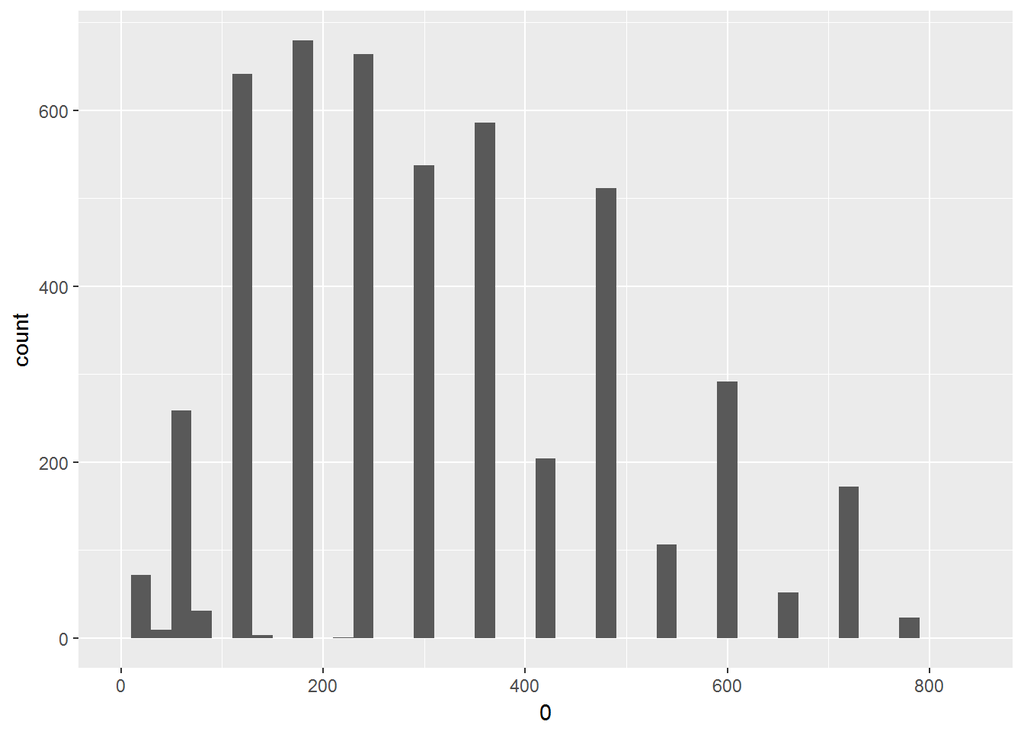

We notice above that a large number of subjects have lower levels of sedentary activity. We will explore this further in the next section when we break this down by gender and age.

We are looking at a data set of adults (min. age here is 20 years), and we know that a desirable total cholesterol level for adults without heart disease is less than 200 mg/dL. Let us look at the distribution of total cholesterol level for our data set.

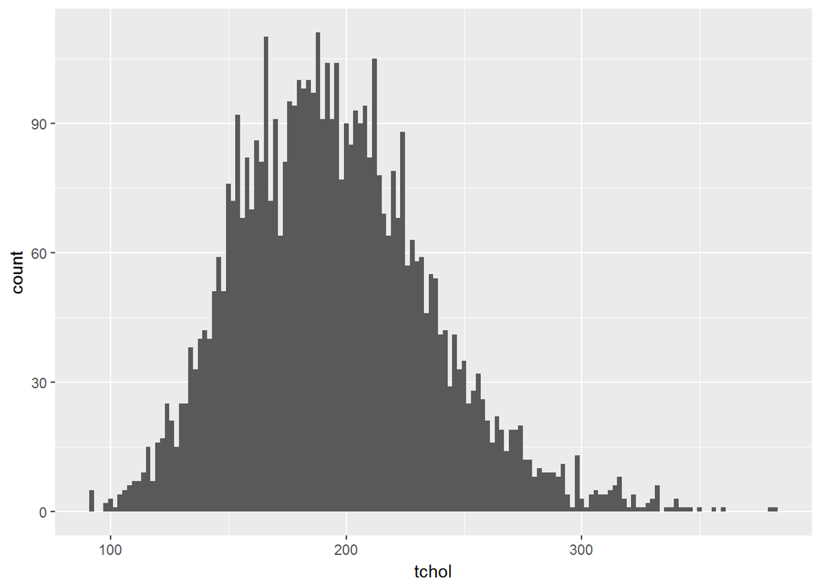

%age of males at risk due to low HDL:

```
## [1] 61.25309
```

%age of females at risk due to low HDL:

```
## [1] 12.81639
```

We notice from the above that the proportion of men at risk of heart disease due to low HDL is approximately 5 times greater than women.

We will cover blood pressure as part of multivariate analysis, as there is no universal guideline on upper and lower thresholds. These are both, age and gender dependent.

# Univariate Analysis

### What is the structure of your dataset?

There are 6482 observations of 21 variables in the original dataset. Eliminating incomplete records and stripping out identifers and other redundant variables that will not add value here, we finally have a dataset of 4915 observations of 15 variables. There are 6 unordered factor variables (gender, marital status, walking or biking, obese, work pattern and recreational activity pattern) and 9 numeric variables (age, total cholestrol, hdl, systolic blood pressure, diastolic blood pressure, weight, height, bmi and minutes of sedentary activity).

Some immediate observations are:

1. There are almost equal numbers of males and females in the dataset.
2. Just over half of the respondents are married.
3. Approximately 85% respondents are not classified as obese, i.e. their BMI < 35.
4. Likewise, looking at the 3rd quartile figures for hdl and total cholestrol and comparing these to healthy levels, it is evident that the data set here consists of predominantly non-obese individuals.
5. About 40% of the people surveyed are engaged in at least moderate work activity. About 46% are engaged in at least moderate recreational activity. However, only around a quarter of the subjects walk or bike. Overall, around three-quarters of the respondents are active in some way.
6. There is a higher number of people in the dataset, both male and female, in the 78-81 age range.
7. Higher numbers of individuals exhibit low sedentary activity and there is very little difference between male and female subjects here.
8. The proportion of men at risk of heart disease due to low HDL is approximately 5 times greater than women.

### What is/are the main feature(s) of interest in your dataset?

The main feature of interest in the dataset is BMI and obsesity. I would like to explore the factors that correlate to a high bmi.

### What other features in the dataset do you think will help support your investigation into your feature(s) of interest?

I imagine that gender, age, HDL, total cholestrol, work pattern, recreational activity pattern, walking/biking and sedentary activity - all affect bmi. It is important to note though that recommended values for these features will vary with age and gender.

### Did you create any new variables from existing variables in the dataset?

Yes, I created 2 new variables in order to remove redundancy from pairs of existing variables, and consolidate into single factor variables. So, I combined vigorous/moderate/no work activity as a single factor variable “workpattern” based on given “Yes”, “No” responses for the underlying variables. Similarly, I combined vigorous/moderate/no recreational activity using a new factor variable “recrpattern”. I then removed the base variables.

I also created a new factor variable called “active”. This variable contains a “Yes” if the subject engaged in moderate or vigorous work activity, moderate or vigorous recreational activity, or walking/biking. Otherwise, it is “No”.

### Of the features you investigated, were there any unusual distributions? Did you perform any operations on the data to tidy, adjust, or change the form of the data? If so, why did you do this?

I removed incomplete records from the dataset. The age distribution is skewed in that there is a larger proportion of subjects in the age range 78-80, recorded for both genders. I will analyse this group in some more detail in the bivariate and multivariate analyses sections. As explained above, I tidied up the work activity and recreational activity data into single factor variables to consolidate data and remove redundancy. I also created a new “active” variable to record a simple Yes/No based on any activity recorded for the subject.

# Bivariate Plots Section

Let us first explore correlations between pairs of numeric variables to glean any strong correlations:

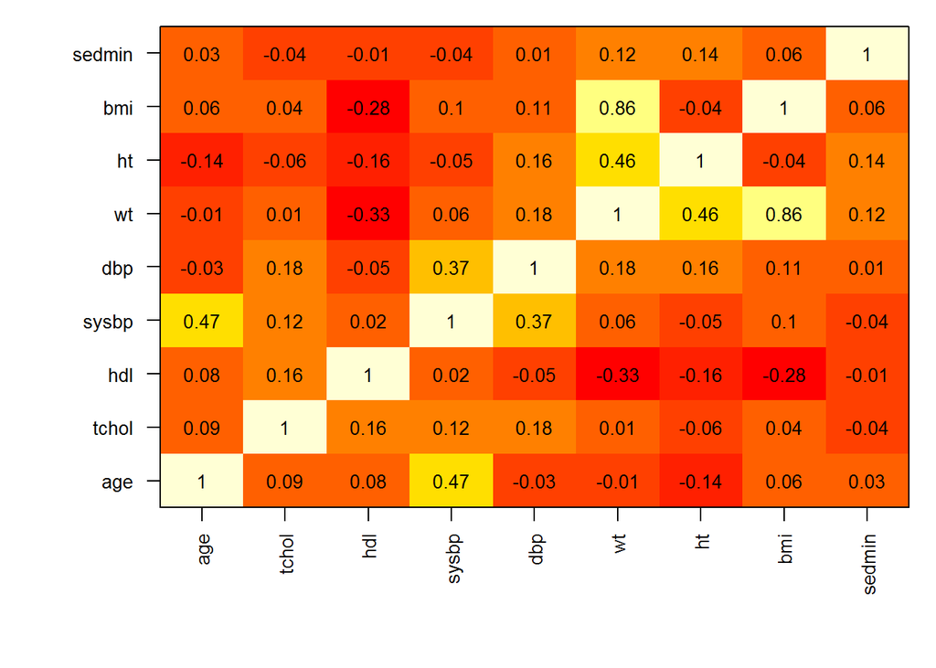

We now move our focus to including categorical variables.

How does gender relate to bmi?

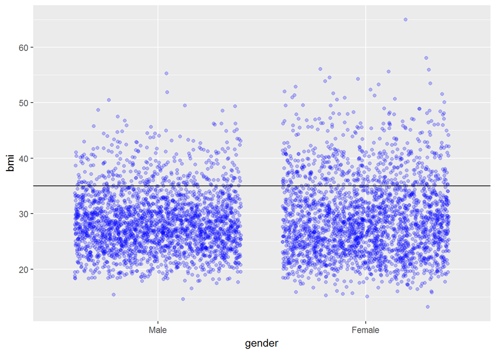

We see from this plot that more females than males are obese, i.e. more females than males have a bmi > 35. We will explore this relationship taking age and activity levels into consideration as part of multivariate analysis.

Is there an interesting relationship between marital status and bmi?

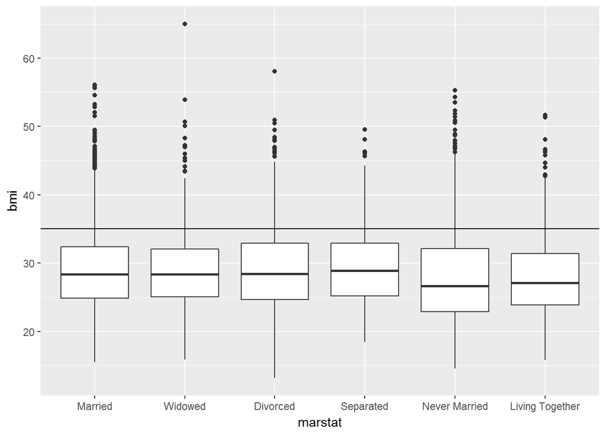

Next, how does work activity and recreational activity patterns relate to bmi? I would expect to see that as these go from moderate to vigorous, bmi values will be low.

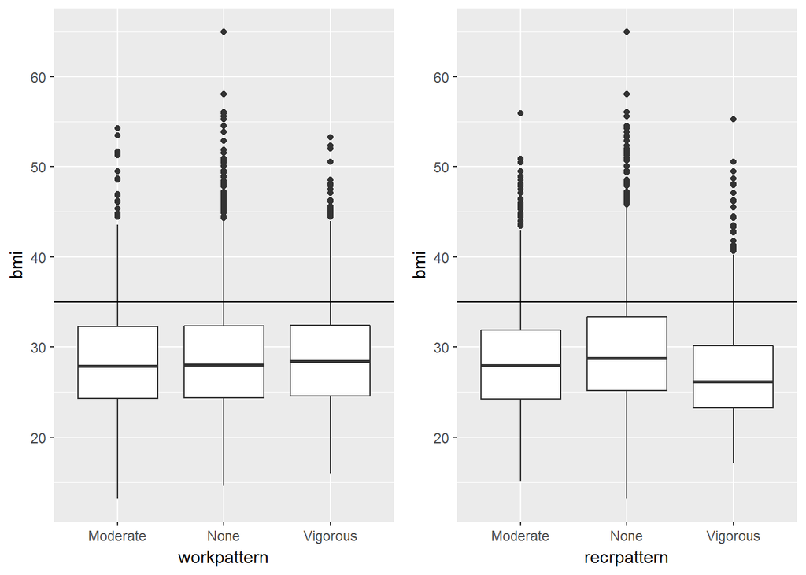

Here, the variation in bmi with recreational activity confirms our hypothesis that individuals with vigorous activity have generally healthier levels of bmi. However, individuals with vigorous work activity do not, on average, seem to be better off than individuals with moderate work activity. Let us explore these two groups further:

```
## # A tibble: 3 x 3
##   workpattern bmi_mean bmi_median
##   <fct>          <dbl>      <dbl>
## 1 Vigorous        29.1       28.4
## 2 None            28.9       28.0
## 3 Moderate        28.7       27.9
```

We see above that there is hardly any noticable difference in bmi levels with work activity. In fact, bmi levels for individuals with vigorous work activity is marginally higher. Nevertheless, median levels in all three cases are below the obesity threshold.

What about the impact of walking or biking on bmi? Again, I would expect these individuals to have lower levels of bmi on average.

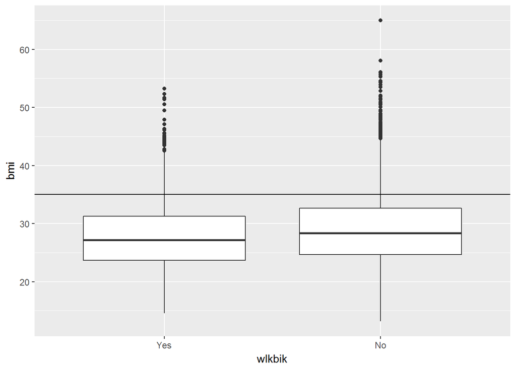

This is as expected. And what about sedentary minutes per week?

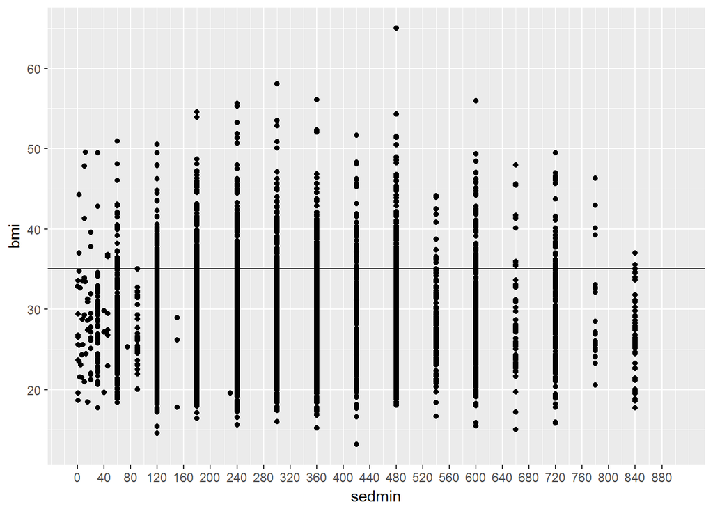

Let us isolate this group and look at their other parameters:

```
## # A tibble: 35 x 4
##    sedmin bmi_mean bmi_median     n
##    <fct>     <dbl>      <dbl> <int>
##  1 840        27.1       26.6    46
##  2 780        29.4       26.0    23
##  3 720        29.5       28.6   172
##  4 660        28.5       27.4    52
##  5 600        29.9       29.1   292
##  6 540        28.2       27.1   106
##  7 480        29.9       29.0   511
##  8 420        28.8       27.4   204
##  9 360        28.8       28.0   586
## 10 300        29.3       28.5   537
## # ... with 25 more rows
```

The above plot indicates that the highest levels of bmi are for individuals with sedentary activity = 12 minutes per week. Other groups with lower levels of bmi have also reported wildly varying levels of sedentary activity! However, we see here that groups with varying levels of sedentary activity are oversampled or undersampled. Also, the wide range of sedentary minutes suggests that these numbers have possibly not been accurately defined and/or reported. Hence there are no clear conclusions to be drawn from the relationship between sedentary minutes per week and bmi.

Are their interesting observations in bmi with age?

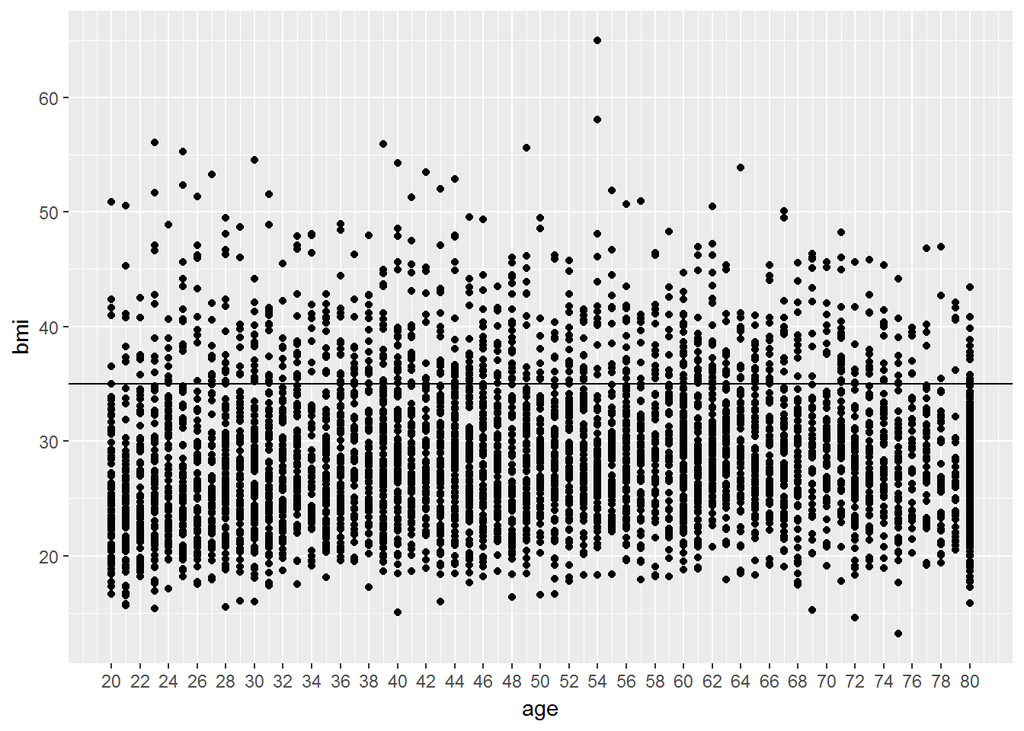

Here, we confirm that majority of the indviduals in the data set have healthy levels of bmi. There are 2 outliers at age 54, and a few more at age 49 and 64.The variation in bmi is smaller with increase in age. 80 year olds in particular have generally excellent levels of bmi.

Let us consider variation in median bmi with age, ignoring the top 5% of the bmi data.

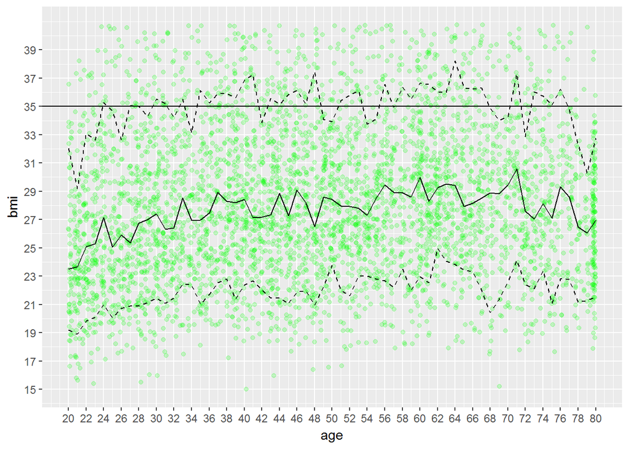

The above graph shows occasional peaks in median, 10th and 90th quantile bmi with age, but there are no alarming signs here. The highest 90th quantile bmi values occur at age 41 (start of the mid-life crisis!), 48, 64 and 71. At all other ages, individuals display healthy levels of bmi. These findings must again show gender variations which we shall explore in the next section.

Are there any findings to be seen for total cholestrol or hdl vs. bmi ?

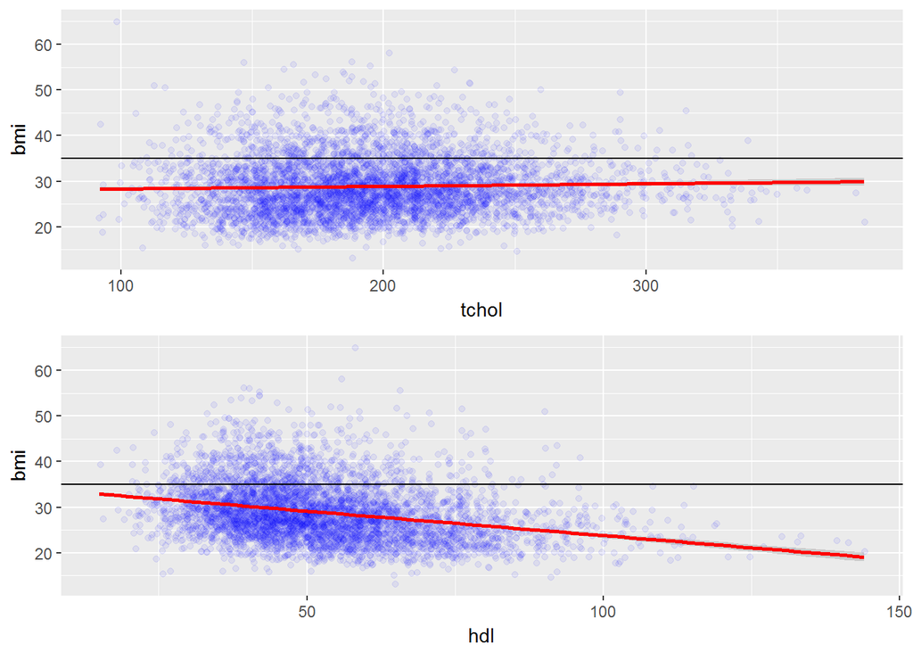

There is clearly no linear relationship between total cholestrol and bmi. hdl shows a slight downward trend vs. bmi but let us ignore the top 5% of the hdl values and re-plot.

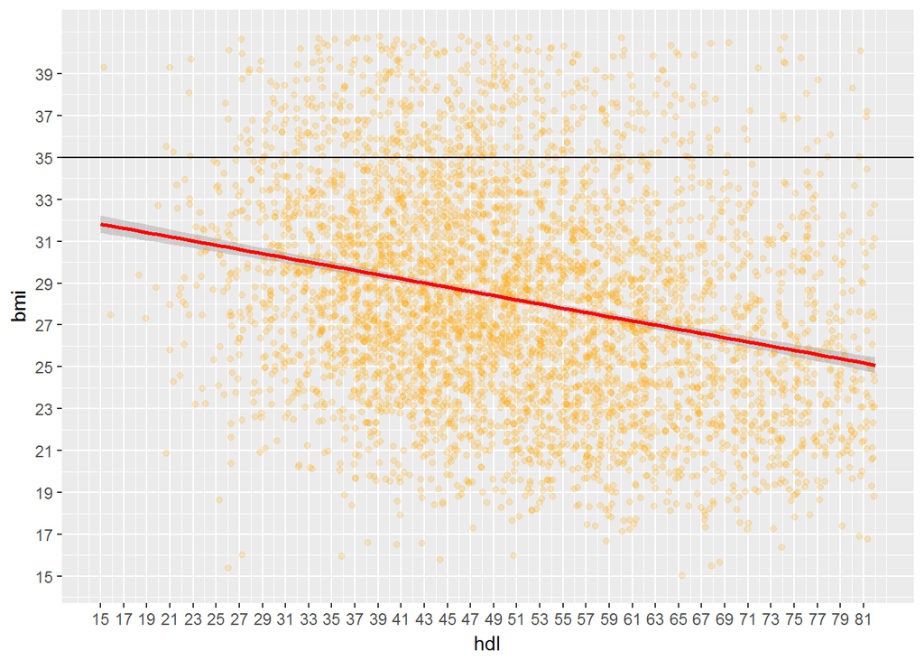

Finally, let us see if we can glean any insights from plotting blood pressure vs. bmi

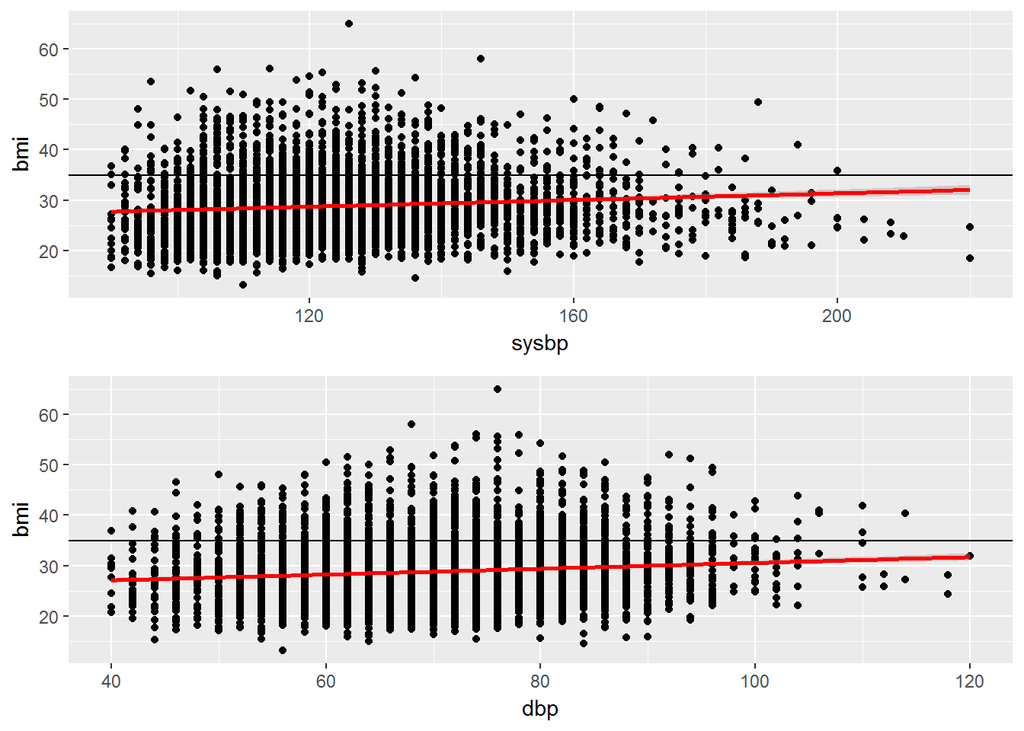

There is no clear correlation between blood pressure in general vs. bmi. We do notice that there are individuals with normal levels of bp, but worryingly high levels of bmi.